# spectralR: Spectral reflectance visualisations for user-defined areas

Oleh Prylutskyi

2022-04-20

## Introduction

The `spectralR` package ([homepage and source code](https://github.com/olehprylutskyi/spectralR)) is aimed to obtain, process, and visualize spectral reflectance data for the user-defined earth surface classes for visual exploring in which wavelengths the classes differ. User-defined classes might represent different habitat or vegetation types, crops, land uses, landscapes, or other types of territories or water areas. Input should be a shapefile with polygons of surface classes (it might be different habitat types, crops, or other things). So far, the single source of spectral data is [Sentinel 2 Level 2A](https://sentinels.copernicus.eu/web/sentinel/missions/sentinel-2) satellite mission optical bands pixel data so far, obtained through the [Google Earth Engine](https://earthengine.google.com/) service.

The initial purpose of `spectralR` development was to quickly and visually explore the differences in spectral reflectance patterns for supervised vegetation (and, widely, habitat) mapping. While machine learning classification methods, such as [RandomForest](https://en.wikipedia.org/wiki/Random_forest), typically utilize the full set of available spectral data (satellite bands), we observed that highly similar habitat types (e.g., different types of grasslands, floodplain habitats) may have similar reflectance values during one season and different for another, so time-series reflectance data are also needed. Without the preliminary selection of the most discriminating satellite bands for given habitat types in given conditions, the models became overfitted and required extensive machine resources for calculation.

The [first version](https://github.com/olehprylutskyi/habitat-spectral-reflectance) of our product was based on three code snippets, two written for R (shapefile preparation and visualization of the results) and one for Google Earth Engine for satellite image preparation and spectral data sampling itself. That approach, though, required a bunch of manual operations, as well as downloading big files on a local machine. So we moved to the recent [rgee](https://r-spatial.github.io/rgee/) R package, which provides a bridge between R and Python API for Google Earth Engine. All the operations with satellite images now run in a cloud, and the obtained pixel data is visualized locally afterward. Therefore, the most resource-hungry operations do not overload your local machine even despite the large extent of input data. However, a stable Internet connection is required for using the API.

For using `rgee` you should have a Google Earth Engine account. If you don’t, first [register](https://earthengine.google.com/new_signup/) using your Google account.

Depending on the operating system you use and your current Python configuration, it may require the installation of additional R and Python packages for running `rgee`. See the following links for instructions. See also [Quick Start User’s Guide](https://www.rdocumentation.org/packages/rgee/versions/1.0.7), [Official documentation](https://r-spatial.github.io/rgee/index.html), and the [source code](https://github.com/r-spatial/rgee) of rgee for solving issues that arise during installation and setting up.

We strongly encourage you to follow the official `rgee` installation guide and pay attention to the messages that arrive during installation.

The overall workflow is following:

1. Load user’s ESRI shapefile containing polygons for user-defined surface classes, as well as the text or numerical field with classes names (labels).
2. Apply `rgee` functionality to retrieve multi-band pixel data for classes polygons from the Google Earth Engine service.
3. Visualize retrieved pixel data locally, using `ggplot2` approach.

Essential requirements:

- Stable Internet connection (for using API)
- Installed and correctly pre-configured Python environment (v. 3.5 or above)
- Active Google Earth Engine account

## Essential preparations

### Install and set up `rgee`

```r
remotes::install_github("r-spatial/rgee")
```

Load the library:

```r
library(rgee)
```

It is necessary just once to complete the installation of the dependencies:

```r
ee_install()
```

If something went wrong at this step, see `rgee`’s [installation guide](https://r-spatial.github.io/rgee/index.html#installation)

Check non-R dependencies

```r
ee_check()
```

`rgee` developers recommend installing the version of the Earth Engine Python API which `rgee` was tested with, using the following command. Despite it calls “upgrade”, it might actually downgrade your version of `earthengine_api`.

```r
ee_install_upgrade()
```

Initialize the Google Earth Engine API for current session:

```r
ee_Initialize()
```

At this step, you would be prompted to link your Google Earth Engine account with `rgee`. Follow instructions in the R console, and you will be redirected to a web browser for logging into your Google Earth Engine account to confirm access rights. An authorization code generated during this step should be pasted into R console to finalize authentification.

If everything is OK at the last step and you see a message of successful initiation of API with your GEE username in the console, - congratulations, you managed to install and configure rgee`rgee`!

Pay attention that `rgee` uses `earthengine_api` package, which depends on Python. That’s why we need to set up a local Python environment for using `rgee`.

Unfortunately, you have to repeat environment setting and re-authorization each time Python gets updates. For actively updated operating systems, like regular versions of Ubuntu, that’s quite annoying. On the other hand, this built-in repairing system protects you from accidentally breaking the `earthengine` Python environment during installation or using any other Python-related tools, which is convenient at least if you are such a weak Python user as me. If you get an error message

> “The current Python PATH: /home/user/.virtualenvs/rgee/bin/python does not have the Python package”earthengine-api” installed. Are you restarted/terminated your R session after install miniconda or run ee_install()?”

then proceed instruction appeared in R console, which will help you to delete your previous configuration and set up it again.

### Installation of the other dependencies

```r
install.packages("geojsonio")
```

### Installation of spectralR

`spectralR` can be installed from **GitHub** sources so far, although we are planning to land it on CRAN soon.

```r
library(remotes)
install_github("olehprylutskyi/spectralR")
```

We offer two use-cases for getting users familiar with the functionality of spectralR. The first one is a small-size area in the Kharkiv region, Ukraine, where National Park “Homilsha Forests” is situated, with 8 polygons for 5 land use classes – let’s call it “small data”. The second - a “large data” - is the 380 hand-drawing polygons of 26 different habitat types (according to the EUNIS classification system) of Buzky Gard National Park, Mykolaiv region, Ukraine. End users don’t expect to notice large differences in workflow, but under the hood we implemented two different algorithms for either “small” or “large” spatial data, which will be explained later.

## Use case 1. Basic habitat types of ‘Homilsha Forests’ National Park and neighborhoods.

### Environment preparation

```r
# Reset R's brain before new analysis session started. It will erase all the objects stored in
# R memory, while keep loaded libraries.
rm(list = ls())

# Load required packages
library(tidyverse)
library(rgee)
library(sf)
library(geojsonio)
library(reshape2)
library(spectralR)
```

### Upload and process vector data

Function `prepare.vector.data` takes shapefile with polygons of different classes of surface (habitats, crops, vegetation, etc.) and retrieves ready-for-sampling `sf` object. One should specify shapefile name (should be within working directory, using absolute paths were not tested) and the name of the field that contains class labels. The function extracts geometries of all polygons, marks them with custom labels (‘label’), and automatically assigns integer class ID (‘class’) for each entry. The last variable is required because the Google Earth Engine sampler respects only numerical class ID - don’t delete any field! Don’t panic, the resulting dataframe will be marked according to your custom labels, not hard-to-memorizable numbers.

While preparing a shapefile with custom polygons (e.d., in [QGIS](https://qgis.org/en/site/)), try to follow recommendations: * if possible, draw polygons in homogeneous landscapes, avoid class mixture; * keep geometries simple, if possible. Avoid multipolygons, holes inside polygons, etc.; * tiny polygons (same size as satellite imagery resolution or lesser) tend to prodice a stronger “edge effect”; * few big polygons are easier to process than a lot of small ones; * GEE has its own memory limitation, which may result in extended processing time.

```r
# Extract polygons from shapefile and prepare sf object with proper structure
sf_df <- prepare.vector.data(system.file("data/test_shapefile.shp", package = "spectralR"), "veget_type")
```

Explore resulting spatial object:

```r
head(sf_df)
```

```
#> Simple feature collection with 6 features and 2 fields
#> Geometry type: POLYGON
#> Dimension:     XY
#> Bounding box:  xmin: 36.34492 ymin: 49.55411 xmax: 36.54525 ymax: 49.66422
#> Geodetic CRS:  WGS 84
#>               label class                       geometry
#> 1 coniferous_forest     1 POLYGON ((36.35601 49.62186...
#> 2             water     5 POLYGON ((36.50612 49.57447...
#> 3              reed     4 POLYGON ((36.43128 49.59587...
#> 4          cropland     2 POLYGON ((36.42945 49.62938...
#> 5            meadow     3 POLYGON ((36.34492 49.64281...
#> 6            meadow     3 POLYGON ((36.37633 49.66116...
```

The example above uses an internal test shapefile. To use your own file, put all the shapefile into your working directory and use following syntax:

```r
# sf_df <- prepare.vector.data("your-shapefile-within-working-directory-name.shp", "name-of-the-field-with-class-labels")
```

### Obtain pixel values from Sentinel 2A image collection

Function `get.pixel.data` is the heart of `spectralR`. It takes `sf` polygon object obtained at the previous step and retrieves a data frame with brightness values for each pixel intersected with polygons for each optical band of Sentinel-2 sensor, marked according to the label of surface class from the polygons. `get.pixel.data` firstly converts `sf` object into GEE feature collection, then prepares satellite image for pixel sampling and performs sampling, and finally exports resulting object back into an R data frame (non-spatial now).

One of the most tricky and issues-causing steps of this procedure is the conversion between R’s `sf` object and GEE’s feature collection. `rgee` implements three way to do so: - through the JSON translator (`getInfo`, default) - using Google Drive (`getInfo_to_asset`) - using Google Cloud Storage (`gcs_to_asset`)

The first one is the most straightforward and quick, but usable only for small data (less than 15000 entries, or 1.5 MB local files). The other two require transient storage to store your data between conversions (because Earth Engine is Google’s service and seamlessly integrated with plenty of Google services).

In `spectralR`, we use the first two methods. `get.pixel.data` assesses the size of your `sf` object or feature collection, then activates either `getInfo` or `getInfo_to_asset` pathway. If you data is considered being “small”, `getInfo` will be used and you will notice nothing special. But, if your data is larger than our arbitrary threshold, the method `getInfo_to_asset` will be activated, and you may be prompted to authorize in Google Drive and allow `rgee` to access GDrive files and folders. In such a case, please follow instructions in the R console and then in your web-browser. You may do it once you perform your first large query, - you credits will be stored in your local `earthengine` environment.

After authorization and first use, folder *rgee_backup* will be created in your Google Drive storage, when all the intermediate files will be stored. Though `get.pixel.data` re-write objects each time it will be launched, we strongly recommend cleaning *rgee_backup* folder in your Drive manually from time to time. Apparently, if you run out of storage, `get.pixel.data` won’t be able to use your Google Drive as mediating storage, and you will receive an error.

To use `get.pixel.data`, we need to specify some values:

- polygons of surface classes as an `sf` object, prepared at the previous step;
- starting day for Sentinel image collection, in “YYYY-MM-DD” format. See Note 1 below;
- final day for Sentinel image collection, in “YYYY-MM-DD” format;
- cloud threshold (maximum percent of cloud-covered pixels per image) by which individual satellite imageries will be filtered;
- scale of resulting satellite images in meters (pixel size). See Note 2 below;

The Resulting pixel data will be saved within a working directory and can be loaded during the next sessions.

**Note 1**. Particular satellite imagery is typically not ready for instant sampling - it contains clouds, cloud shadows, aerosols, and may cover not all the territory of your interest. Another issue is that each particular pixel slightly differs in reflectance between images taken on different days due to differences in atmospheric conditions and angle of sunlight at the moments images were taken. The Google Earth Engine has its own build-in algorithms for image pre-processing, atmospheric corrections and mosaicing, which allows to obtain a ready-to-use, rectified image. The approach used in `spectralR` is to find a median value for each pixel between several images within each of 10 optical bands, thereby making a composite image. To define a set of imageries between which we are going to calculate the median, we should set a timespan of image collection. Sentinel-2 apparatus takes picture once a 5 days, so if you set up month-long timesnap, you can expect that each pixel value will be calculated based on 5 to 6 values (remember, some images might appear unsatisfactory cloudy).

**Note 2**. The finest resolution for Sentinel data is 10 m, while using larger-scale values decreases the required computational resources and size of the resulting data frame. Although sampling satellite data performs in a cloud, there are some limitations for geocalculations placed by GEE itself. If you are about to sample large areas, consider setting a higher ‘scale’ value (e.g., 100, 1000). Read more in GEE [best practices](https://developers.google.com/earth-engine/guides/best_practices).

```r
# Get pixel data
reflectance = get.pixel.data(sf_df, "2019-05-15", "2019-06-30", 10, 100)

# Save pixel data for further sessions
save(reflectance, file = "reflectance_test_data")
```

Here we choose the 100 m scale (pixel size for resulting imagery is 100x100 m), which resulted in sampling dataset of 2060 rows. Finer pixel size would result in a larger sampling dataset, which would require using moderating storage (see use case 2).

Let’s have a look at the resulting data:

```r
head(reflectance)
```

```
#>       B11     B12      B2      B3      B4      B5      B6      B7      B8
#> 1 0.11700 0.06375 0.02790 0.04240 0.03460 0.06740 0.15810 0.18520 0.19275
#> 2 0.11065 0.05955 0.02720 0.04155 0.03320 0.06475 0.15590 0.18180 0.18900
#> 3 0.10665 0.05815 0.02640 0.04085 0.03210 0.06365 0.15095 0.17770 0.18440
#> 4 0.11265 0.06320 0.02945 0.04350 0.03540 0.06735 0.16075 0.18935 0.19675
#> 5 0.10885 0.05875 0.02720 0.04130 0.03315 0.06435 0.15470 0.18120 0.18840
#> 6 0.11825 0.06630 0.02800 0.04300 0.03700 0.06905 0.15030 0.17590 0.18225
#>       B8A             label
#> 1 0.19995 coniferous_forest
#> 2 0.19565 coniferous_forest
#> 3 0.19280 coniferous_forest
#> 4 0.20490 coniferous_forest
#> 5 0.19500 coniferous_forest
#> 6 0.19050 coniferous_forest
```

We have a data frame with the number of rows equal to the number of sampled “pixels” of satellite image and 10 variables with reflectance values for each optical band of Sentinel 2. Each sampled pixel has a label of a surface class of the user’s polygon it intersected.

### Visualize results

First of all, one should explore the quality and comprehensiveness of obtained pixel data.

```r
load(file = "./reflectance_test_data") # restore previously saved pixel data

summary(factor(reflectance$label)) # how many pixels in each class?
```

```
#> coniferous_forest          cropland            meadow              reed
#>              1270               165                35               144
#>             water
#>               446
```

For reliable results, it is recommended to keep similar size of each surface class. Classes which represented by few sampled pixels, should be excluded from the further analysis.

Visual overview of pixel data

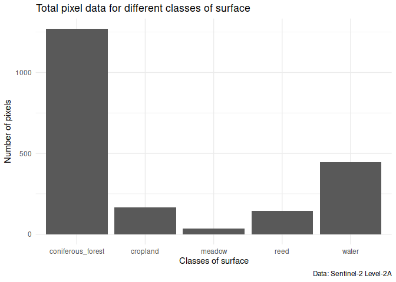

```r
# Number of spectral values for different classes
ggplot(reflectance, aes(x=label))+
  geom_bar()+
  labs(x = 'Classes of surface', y = 'Number of pixels',
       title = "Total pixel data for different classes of surface",
       caption = 'Data: Sentinel-2 Level-2A')+
  theme_minimal()
```

Depending on the data size, it may take some time to process.

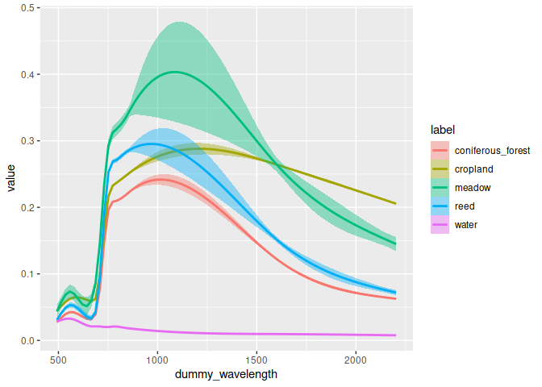

```r
# Make a ggplot object
p1 <- spectral.curves.plot(reflectance)
# Default plot
p1
```

Since the output of `spectral.curves.plot` is `ggplot` object, we can apply any tools provided by `ggplot2` package to make it more visually pleasant.

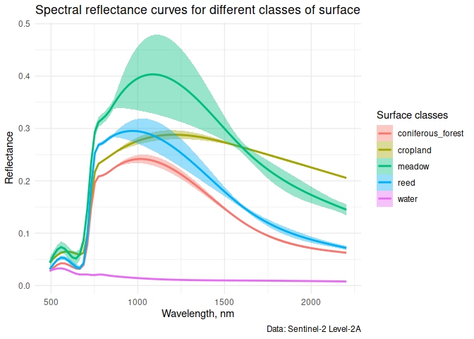

```r
# Customized plot
p1+
  labs(x = 'Wavelength, nm', y = 'Reflectance',
       colour = "Surface classes",
       fill = "Surface classes",
       title = "Spectral reflectance curves for different classes of surface",
       caption = 'Data: Sentinel-2 Level-2A')+
  theme_minimal()
```

You can save the plot as a *.png (or other common graphical formats) file using `ggsave` or `png()` functions

```r
ggsave("Spectral_curves_usecase1.png", width=16, height=12, unit="cm", dpi=300)
```

Function `stat.summary.plot` make a plot with statistical summary of reflectance values (mean, mean-standard deviation, mean+standard deviation) for defined classes of surface. Giving as input reflectance data, the function returns ggplot2 object with basic visual aesthetics. Default aesthetics are line with statistical summary for each satellite band ([geom_line](https://ggplot2.tidyverse.org/reference/geom_linerange.html) + [geom_pointrange](https://ggplot2.tidyverse.org/reference/geom_path.html)).

Wavelengths values (nm) acquired from mean known value for each optical band of [Sentinel 2](https://en.wikipedia.org/wiki/Sentinel-2) sensor.

```r
# Make a ggplot object
p2 <- stat.summary.plot(reflectance)
```

```
#> Warning: Ignoring unknown parameters: width
```

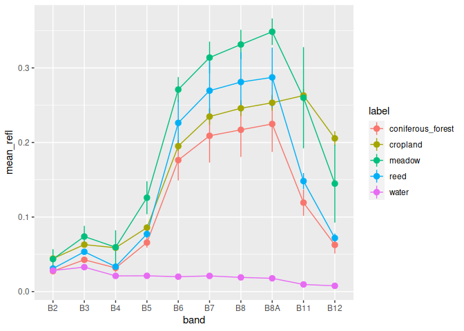

```r
# Default plot
p2
```

Add a touch of customization and save as a picture.

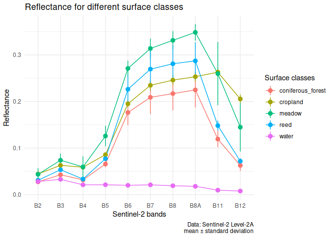

```r
# Customized plot
p2 +
  labs(x = 'Sentinel-2 bands', y = 'Reflectance',
       colour = "Surface classes",
       title = "Reflectance for different surface classes",
       caption='Data: Sentinel-2 Level-2A\nmean ± standard deviation')+
  theme_minimal()
```

Save the plot as a *.png file

```r
ggsave("Statsummary_usecase1.png", width=16, height=12, unit="cm", dpi=300)
```

Function `violin.plot` helps to visualize a reflectance as violin plots for each surface class per satellite bands. It gets reflectance data as input and return ggplot2 object with basic visual aesthetics. Default aesthetics is [geom_violin](https://ggplot2.tidyverse.org/reference/geom_violin.html).

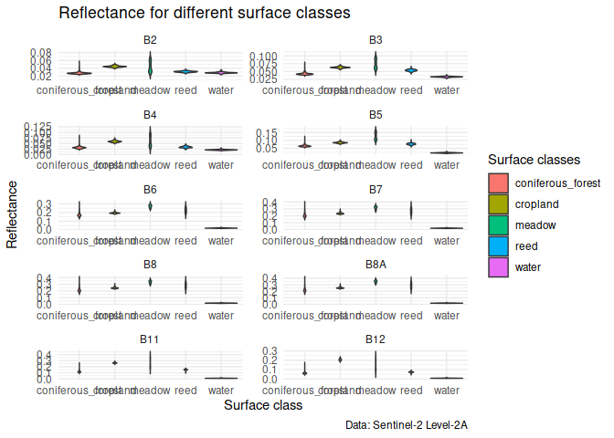

```r
# Make a ggplot object
p3 <- violin.plot(reflectance)

# Customized plot
p3 +
  labs(x='Surface class',y='Reflectance',
       fill="Surface classes",
       title = "Reflectance for different surface classes",
       caption='Data: Sentinel-2 Level-2A')+
  theme_minimal()
```

```r
# Save the plot as a *.png file
ggsave("Violins_usecase1.png", width=22, height=16, unit="cm", dpi=300)
```

## Use case 2. Habitats of Buzky Gard National Park, Mykolaiv region, Ukraine.

Environment preparation

```r
# Reset R's brain before new analysis session started. It will erase all the objects stored in
# R memory, while keep loaded libraries.
rm(list = ls())

# Load required packages
library(tidyverse)
library(rgee)
library(sf)
library(geojsonio)
library(reshape2)
library(spectralR)
```

Upload and process vector data

```r
# Extract polygons from shapefile and prepare sf object with proper structure
sf_df <- prepare.vector.data(system.file("data/SouthernBuh-habitats_shapefile.shp", package = "spectralR"), "eunis_2020")
```

Explore resulting spatial object:

```r
head(sf_df)
```

```
#> Simple feature collection with 6 features and 2 fields
#> Geometry type: POLYGON
#> Dimension:     XY
#> Bounding box:  xmin: 30.96412 ymin: 47.91221 xmax: 31.06714 ymax: 48.01866
#> Geodetic CRS:  WGS 84
#>   label class                       geometry
#> 1   R1B    11 POLYGON ((31.05245 47.92259...
#> 2   R1B    11 POLYGON ((31.06686 47.91231...
#> 3   U33    22 POLYGON ((30.96416 48.01731...
#> 4   R1B    11 POLYGON ((30.96983 48.01847...
#> 5   R12     9 POLYGON ((30.97225 48.01432...
#> 6   U33    22 POLYGON ((30.96804 48.01308...
```

Get reflectance values

```r
reflectance = get.pixel.data(sf_df, "2019-05-15", "2019-06-30", 10, 10)

# save pixel data for further sessions
save(reflectance, file = "reflectance_BG_data")
```

Quantitative overview of pixel data

```r
load(file = "./reflectance_BG_data") # restore previously saved pixel data

summary(factor(reflectance$label)) # how many pixels in each class?
```

```
#>  C2.2  C2.3    J1  J3.2  J4.2    J5   Q51   Q53   R12   R1A   R1B   R21   R36
#>   741  3054 11204   983   447    87  1276     3   659    52  1448   310    49
#>   S35   S36   S91   T11   T13   T19   T1E   T1H   U33   V11   V34   V38   X18
#>   694   220     4   829   331   294    72 14372   165 48778    18  4717   130
```

Spectral reflectance curves for different habitat types

```r
# Create basic ggplot object
p1 <- spectral.curves.plot(reflectance)
```

```
#> Warning in mask$eval_all_mutate(quo): NAs introduced by coercion
```

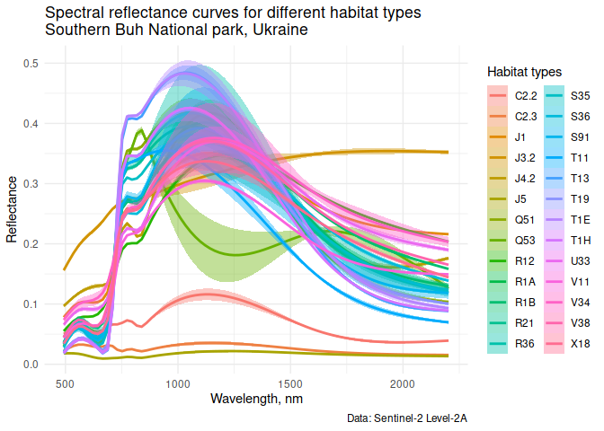

```r
# Plotting
p1+
  labs(x = 'Wavelength, nm', y = 'Reflectance',
       colour = "Habitat types",
       fill = "Habitat types",
       title = "Spectral reflectance curves for different habitat types\nSouthern Buh National park, Ukraine",
       caption = 'Data: Sentinel-2 Level-2A')+
  theme_minimal()
```

Statistical summary for each habitat type

```r
# Create basic ggplot object
p2 <- stat.summary.plot(reflectance)
```

```
#> Warning in mask$eval_all_mutate(quo): NAs introduced by coercion
#> Warning: Ignoring unknown parameters: width
```

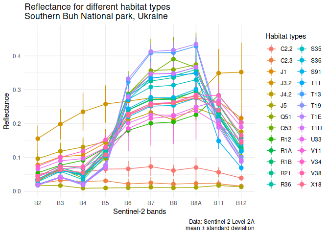

```r
# Plotting
p2 +
  labs(x = 'Sentinel-2 bands', y = 'Reflectance',
       colour = "Habitat types",
       title = "Reflectance for different habitat types\nSouthern Buh National park, Ukraine",
       caption='Data: Sentinel-2 Level-2A\nmean ± standard deviation')+
  theme_minimal()
```

Create violin plots for given habitat types

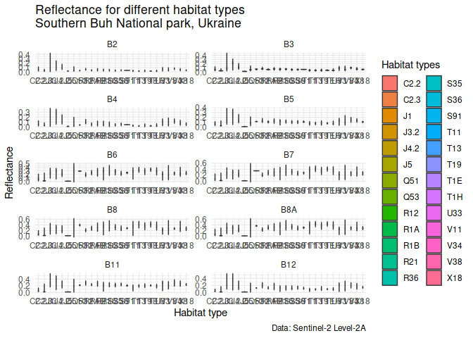

```r
# Create basic ggplot object
p3 <- violin.plot(reflectance)

# Plotting
p3 +
  labs(x='Habitat type', y='Reflectance',
       fill="Habitat types",
       title = "Reflectance for different habitat types\nSouthern Buh National park, Ukraine",
       caption='Data: Sentinel-2 Level-2A')+
  theme_minimal()
```

You also can save and/or transform resulting ggplot objects as you wish, using `ggplot2` and `tidyverse` syntax.